# Ch. 4 Exercises: Probability

Thea Sukianto

January 18, 2021

## Exercise 4.4

Consider a spinner with a $[0,1]$ scale on its circumference. Suppose that the spinner is slanted or magnetized or bent in some way such that it is biased, and its probability density function is $p(x)=6x(1−x)$ over the interval $x\in[0, 1]$.

1. Adapt the program `IntegralOfDensity.R` to plot this density function and approximate its integral. Comment your code. Be careful to consider values of $x$ only in the interval $[0, 1]$. Hint: You can omit the first couple of lines regarding `meanval` and `sdval`, because those parameter values pertain only to the normal distribution. Then set `xlow = 0` and `xhigh = 1` ,and set `dx` to some small value.

```r
source("../DBDA2E-utilities.R")
```

```
##
## Kruschke, J. K. (2015). Doing Bayesian Data Analysis, Second Edition:
## A Tutorial with R, JAGS, and Stan. Academic Press / Elsevier.
```

[output not shown]

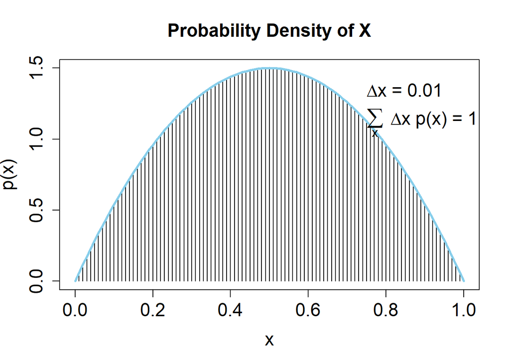

```r
# Graph of normal probability density function, with comb of intervals.
#meanval = 0.0               # Specify mean of distribution.
#sdval = 0.2                 # Specify standard deviation of distribution.
xlow  = 0 # Specify low end of x-axis.
xhigh = 1 # Specify high end of x-axis.
dx = 0.01               # Specify interval width on x-axis
# Specify comb of points along the x axis:
x = seq( from = xlow , to = xhigh , by = dx )
# Compute y values, i.e., probability density at each value of x:
y = 6*x*(1-x)
# Plot the function. "plot" draws the intervals. "lines" draws the bell curve.
openGraph(width=7,height=5)
plot( x , y , type="h" , lwd=1 , cex.axis=1.5
    , xlab="x" , ylab="p(x)" , cex.lab=1.5 ,
    , main="Probability Density of X" , cex.main=1.5 )
lines( x , y , lwd=3 ,  col="skyblue" )
# Approximate the integral as the sum of width * height for each interval.
area = sum( dx * y )
# Display info in the graph.
#text( meanval-sdval , .9*max(y) , bquote( paste(mu ," = " ,.(meanval)) )
      #, adj=c(1,.5) , cex=1.5 )
#text( meanval-sdval , .75*max(y) , bquote( paste(sigma ," = " ,.(sdval)) )
      #, adj=c(1,.5) , cex=1.5 )
text( .75 , .9*max(y) , bquote( paste(Delta , "x = " ,.(dx)) )
      , adj=c(0,.5) , cex=1.5 )
text( .75 , .75*max(y) ,
      bquote(
        paste( sum(,x,) , " " , Delta , "x p(x) = " , .(signif(area,3)) )
      ) , adj=c(0,.5) , cex=1.5 )
```

```r
# Save the plot to an PNG  file.
saveGraph( file = "IntegralOfDensity" , type="png" )
```

2. Derive the exact integral using calculus. Hint: See the example, Equation 4.7.

$\displaystyle\int_0^1 6x(1-x)dx$ $=6\displaystyle\int_0^1 x-x^2dx$ $=6[\frac{x^2}{2}-\frac{x^3}{3}|_0^1]$ $=6\times\frac{1}{6}$ $=1$

3. Does this function satisfy Equation 4.3?

Yes, the above integral is equal to 1, so the function is a legitimate PDF.

4. From inspecting the graph, what is the maximal value of $p(x)$?

1.5 which occurs at x = 0.5.

## Exercise 4.6

School children were surveyed regarding their favorite foods. Of the total sample, 20% were 1st graders, 20% were 6th graders, and 60% were 11th graders. For each grade, the following table shows the proportion of respondents that chose each of three foods as their favorite:

|  | Ice cream | Fruit | French fries |
| --- | --- | --- | --- |
| **1st graders** | 0.3 | 0.6 | 0.1 |
| **6th graders** | 0.6 | 0.3 | 0.1 |
| **11th graders** | 0.3 | 0.1 | 0.6 |

From that information, construct a table of joint probabilities of grade and favorite food. Also, say whether grade and favorite food are independent or not, and how you ascertained the answer. Hint: You are given p(grade) and p(food|grade). You need to determine p(grade, food).

### Discussion

By the definition of conditional probability, p(grade, food) = p(grade)p(food|grade), so we have:

|  | Ice cream | Fruit | French fries | Total |
| --- | --- | --- | --- | --- |
| **1st graders** | 0.06 | 0.12 | 0.02 | 0.2 |
| **6th graders** | 0.12 | 0.06 | 0.02 | 0.2 |
| **11th graders** | 0.18 | 0.06 | 0.36 | 0.6 |
| **Total** | 0.36 | 0.24 | 0.40 | 1 |

We know that Grade and Food are independent iff p(grade, food) = p(grade)p(food).

But p(1st grade, Ice cream) = 0.06, which is not equal to p(1st grade)p(Ice cream) = 0.2 x 0.36 = 0.072.

Therefore, Grade and Food are not independent.